# Analysis of count/mass systematicity: morphemes and length

Bodo

25/02/2022

## Setup

Load libraries:

```r
library(tidyverse)
library(brms)
library(effsize)
library(patchwork)
```

Print versions for reproducibility (only those that will be reported in the write-up):

```r
R.Version()
```

```
## $platform
## [1] "x86_64-apple-darwin17.0"
##
## $arch
## [1] "x86_64"
##
## $os
## [1] "darwin17.0"
##
## $system
## [1] "x86_64, darwin17.0"
##
## $status
## [1] ""
##
## $major
## [1] "4"
##
## $minor
## [1] "1.1"
##
## $year
## [1] "2021"
##
## $month
## [1] "08"
##
## $day
## [1] "10"
##
## $`svn rev`
## [1] "80725"
##
## $language
## [1] "R"
##
## $version.string
## [1] "R version 4.1.1 (2021-08-10)"
##
## $nickname
## [1] "Kick Things"
```

```r
packageVersion('tidyverse')
```

```
## [1] '1.3.1'
```

```r
packageVersion('brms')
```

```
## [1] '2.16.2'
```

```r
packageVersion('effsize')
```

```
## [1] '0.8.1'
```

```r
packageVersion('patchwork')
```

```
## [1] '1.1.1'
```

Load data:

```r
BECL <- read_csv('../data/BECL.csv')
ELP <- read_csv('../data/ELP_red.csv')
SUBTL <- read.csv('../data/SUBTLEX_US.csv',
                  stringsAsFactors = FALSE) %>% as_tibble()
CMU_full <- readLines('../data/CMU_dict-0.7b.txt') # for final phonemes
CMU <- read_csv('../data/CMU_phoneme_counts.csv') # prepared phoneme counts
OED <- read_csv('../data/OED_processed_etymologies.csv')
```

## Data carpentry and overview

How many count / mass nouns do we have?

```r
nrow(BECL)
```

```
## [1] 11869
```

Around 12,000 nouns.

Check how many there are per category:

```r
BECL %>% count(major_class, sort = TRUE)
```

```
## # A tibble: 4 × 2
##   major_class            n
##   <chr>              <int>
## 1 regular_count       8432
## 2 regular_mass        2425
## 3 both_mass_count      697
## 4 neither_mass_count   315
```

Make a plot of this:

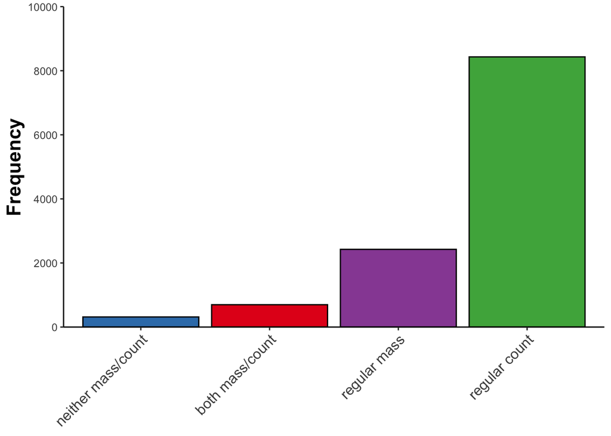

```r
# Plot basics:

type_p <- BECL %>%
  count(major_class, sort = TRUE) %>%
  mutate(major_class = str_replace_all(major_class, '_', ' '),
         major_class = ifelse(major_class == 'both mass count',
                              'both mass/count', major_class),
         major_class = ifelse(major_class == 'neither mass count',
                              'neither mass/count', major_class)) %>%
  ggplot(aes(x = reorder(major_class, n),
             y = n,
             fill = major_class)) +
  geom_col(col = 'black')

# Scales and axes:

type_p <- type_p +
  scale_fill_brewer(palette = 'Set1') +
  scale_y_continuous(expand = c(0, 0),
                     limits = c(0, 10000),
                     breaks = seq(0, 10000, 2000)) +
  ylab('Frequency') +
  xlab(NULL)

# Cosmetics:

type_p <- type_p +
  theme_classic() +
  theme(legend.position = 'none',
        axis.text.x = element_text(angle = 45,
                                   hjust = 1,
                                   vjust = 1, size = 12),
        axis.title.y = element_text(face = 'bold',
                                    size = 16))

# Show and save:

type_p
```

```r
ggsave(plot = type_p, '../figures/BECL_counts.pdf',
       width = 4, height = 4)
```

The majority are either count or mass. There are very few ‘elastics’ or ‘neither’. It’s hard to formulate predictions for these, so we will exclude them. Along the way, we count how many we exclude.

```r
# Exclude:

BECL <- filter(BECL,
               major_class %in% c('regular_count',
                                  'regular_mass'))
```

Lemmatize this. What we’ll do is get the counts of “regular_mass” and “regular_count” per words and get two subsets. In one, we will go by a simple majority rule, e.g., if “regular_mass” > “regular_count” across senses, then a word will be “regular_mass”. In another dataset, we’ll take only those that are never the other.

```r
BECL_wide <- BECL %>%
  count(lemma, major_class) %>%
  pivot_wider(values_from = n,
              names_from = major_class, values_fill = 0)

# Which more?

BECL_wide <- mutate(BECL_wide,
                    cnt_mass = ifelse(regular_count > regular_mass, 'count', NA),
                    cnt_mass = ifelse(regular_count < regular_mass, 'mass', cnt_mass))
```

Check:

```r
# Mass:

filter(BECL_wide, cnt_mass == 'mass')
```

```
## # A tibble: 1,474 × 4
##    lemma         regular_count regular_mass cnt_mass
##    <chr>                 <int>        <int> <chr>
##  1 absenteeism               0            1 mass
##  2 absorption                0            3 mass
##  3 abstinence                0            2 mass
##  4 acceleration              0            1 mass
##  5 acceptability             0            1 mass
##  6 acceptance                0            1 mass
##  7 accessibility             0            1 mass
##  8 acclaim                   0            1 mass
##  9 accuracy                  0            2 mass
## 10 acetone                   0            1 mass
## # … with 1,464 more rows
```

```r
# Count:

filter(BECL_wide, cnt_mass == 'count')
```

```
## # A tibble: 4,890 × 4
##    lemma        regular_count regular_mass cnt_mass
##    <chr>                <int>        <int> <chr>
##  1 aa                       1            0 count
##  2 abbreviation             1            0 count
##  3 aberrancy                1            0 count
##  4 aberration               3            0 count
##  5 abnormality              1            0 count
##  6 abolitionist             1            0 count
##  7 abortion                 1            0 count
##  8 about-face               2            0 count
##  9 abscess                  1            0 count
## 10 absentee                 1            0 count
## # … with 4,880 more rows
```

```r
# Equals:

filter(BECL_wide, is.na(cnt_mass))
```

```
## # A tibble: 177 × 4
##    lemma         regular_count regular_mass cnt_mass
##    <chr>                 <int>        <int> <chr>
##  1 absurdity                 1            1 <NA>
##  2 access                    2            2 <NA>
##  3 accommodation             1            1 <NA>
##  4 accord                    1            1 <NA>
##  5 aggregate                 1            1 <NA>
##  6 ar                        1            1 <NA>
##  7 aspiration                1            1 <NA>
##  8 au                        1            1 <NA>
##  9 audition                  1            1 <NA>
## 10 authority                 2            2 <NA>
## # … with 167 more rows
```

Get rid of the equals:

```r
BECL_wide <- filter(BECL_wide, !is.na(cnt_mass))
```

Create a new column that adds labels ‘mass sometimes count’ and ‘count sometimes mass’:

```r
BECL_wide <- mutate(BECL_wide,
                    cnt_detailed = ifelse(cnt_mass == 'mass' & regular_count > 0,
                                          'mass sometimes count', cnt_mass),
                    cnt_detailed = ifelse(cnt_mass == 'count' & regular_mass > 0,
                                          'count sometimes mass', cnt_detailed))
```

Check:

```r
# Count, sometimes mass:

filter(BECL_wide, cnt_detailed == 'count sometimes mass')
```

```
## # A tibble: 124 × 5
##    lemma          regular_count regular_mass cnt_mass cnt_detailed
##    <chr>                  <int>        <int> <chr>    <chr>
##  1 abstraction                2            1 count    count sometimes mass
##  2 administration             2            1 count    count sometimes mass
##  3 admission                  2            1 count    count sometimes mass
##  4 alarm                      3            1 count    count sometimes mass
##  5 allegory                   2            1 count    count sometimes mass
##  6 alteration                 2            1 count    count sometimes mass
##  7 appeal                     3            1 count    count sometimes mass
##  8 approval                   2            1 count    count sometimes mass
##  9 assessment                 2            1 count    count sometimes mass
## 10 backbone                   3            1 count    count sometimes mass
## # … with 114 more rows
```

```r
# Mass, sometimes count:

filter(BECL_wide, cnt_detailed == 'mass sometimes count')
```

```
## # A tibble: 74 × 5
##    lemma       regular_count regular_mass cnt_mass cnt_detailed
##    <chr>               <int>        <int> <chr>    <chr>
##  1 action                  1            2 mass     mass sometimes count
##  2 alum                    1            3 mass     mass sometimes count
##  3 backing                 1            2 mass     mass sometimes count
##  4 bass                    1            3 mass     mass sometimes count
##  5 carving                 1            2 mass     mass sometimes count
##  6 chum                    1            2 mass     mass sometimes count
##  7 cortex                  1            2 mass     mass sometimes count
##  8 delicacy                1            2 mass     mass sometimes count
##  9 denial                  1            2 mass     mass sometimes count
## 10 expectation             1            2 mass     mass sometimes count
## # … with 64 more rows
```

Add ELP morphology and length data:

```r
ELP <- mutate(ELP, Word = str_to_lower(Word))
BECL_wide <- left_join(BECL_wide, # first df
                       select(ELP, # second df
                              Word, NSyll, NPhon, NMorph),
                       by = c('lemma' = 'Word'))
```

Add SUBTLEX frequencies:

```r
BECL_wide <- left_join(BECL_wide, select(SUBTL, Word, FREQcount),
                       by = c('lemma' = 'Word'))
```

NAs are true zeros here. And log-transform these:

```r
BECL_wide <- BECL_wide %>%
  rename(freq = FREQcount) %>%
  mutate(freq = ifelse(is.na(freq), 0, freq),
         logfreq = log10(freq + 1),

         # Center the logfreq variable:

         logfreq_c = logfreq - mean(logfreq))
```

Add CMU data:

```r
BECL_wide <- left_join(BECL_wide, CMU, by = c('lemma' = 'Word'))
```

Add OED data:

```r
BECL_wide <- left_join(BECL_wide, OED,
                       by = c('lemma' = 'word'))
```

This distribution would have no zeros… since every word has at least one morpheme by definition, well subtract -1 to count “extra morphemes”:

```r
BECL_wide <- mutate(BECL_wide,
                    NMorph_0 = NMorph - 1,
                    NPhon_0 = NPhon - 1,
                    NSyll_0 = NSyll - 1)
```

Clean the `major_etym` field which will be used repeatedly below for plotting, so we want the labels to look nice:

```r
BECL_wide <- mutate(BECL_wide,
                    major_etym = str_to_title(major_etym),
                    major_etym = ifelse(major_etym == 'Other',
                                        'other', major_etym))
```

## Extract subsets

Exclude those without CMU data:

```r
BECL_wide <- filter(BECL_wide, !is.na(AA))
```

Exclude those without etymological data:

```r
BECL_wide <- filter(BECL_wide, !is.na(major_etym))
```

A subset of those that are *only* completely mass or completely count:

```r
BECL_clean <- filter(BECL_wide,
                     cnt_detailed != 'mass sometimes count',
                     cnt_detailed != 'count sometimes mass')
```

Need to get rid of duplicates:

```r
BECL_clean <- filter(BECL_clean,
                     !duplicated(lemma))
```

Check how much each:

```r
BECL_clean %>% count(cnt_detailed) %>%
  mutate(prop = n / sum(n),
         prop = round(prop, 2))
```

```
## # A tibble: 2 × 3
##   cnt_detailed     n  prop
##   <chr>        <int> <dbl>
## 1 count         4353  0.78
## 2 mass          1216  0.22
```

Create a subset with only the monomorphemics to be used later:

```r
mono <- filter(BECL_clean, NMorph == 1)
```

How many of these were of each type for the reduced dataset of monomorphemics?

```r
mono %>%
  count(cnt_mass) %>%
  mutate(prop = n / sum(n),
         prop = round(prop, 1))
```

```
## # A tibble: 2 × 3
##   cnt_mass     n  prop
##   <chr>    <int> <dbl>
## 1 count     2224   0.9
## 2 mass       292   0.1
```

## Etymological analysis

For plotting, get the counts of mass and count nouns:

```r
cnt_mass_counts <- BECL_clean %>%
  count(cnt_mass) %>%
  mutate(N = str_c('N = ', n))
```

How many of each are French or Latin? Make a plot of this:

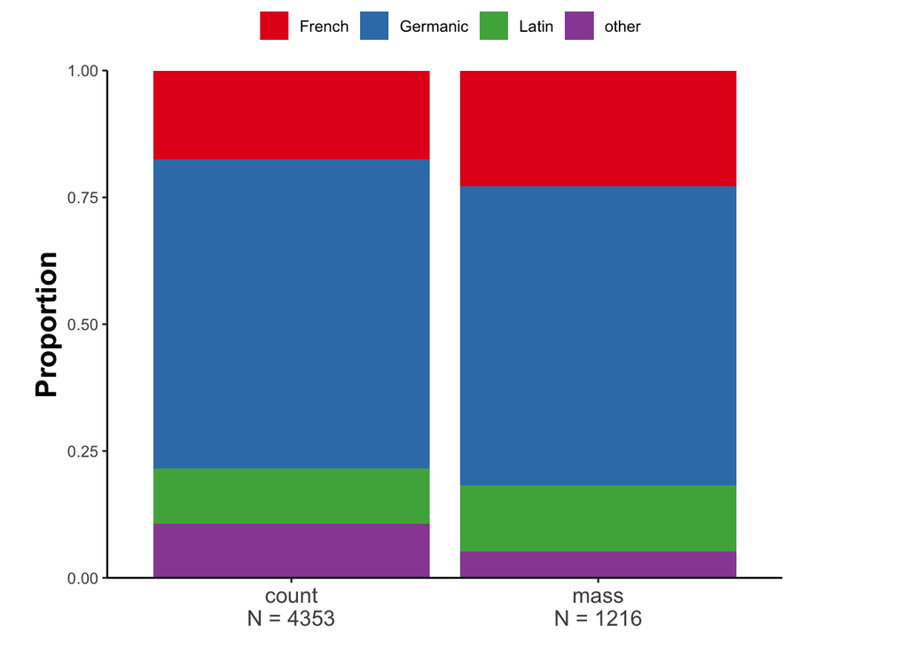

```r
# Plot basics:

etym_p <- BECL_clean %>%
  count(cnt_mass, major_etym) %>%
  group_by(cnt_mass) %>%
  mutate(prop = n / sum(n)) %>%
  left_join(cnt_mass_counts,
            by = c('cnt_mass' = 'cnt_mass')) %>%
  mutate(cnt_mass = str_c(cnt_mass, '\n', N)) %>%

# The actual plot:

  ggplot(aes(x = cnt_mass, y = prop, fill = major_etym)) +
  geom_col()

# Scales and axes:

etym_p <- etym_p +
  scale_fill_brewer(palette = 'Set1') +
  xlab(NULL) +
  ylab('Proportion') +
  scale_y_continuous(expand = c(0, 0),
                     limits = c(0, 1),
                     breaks = seq(0, 1, 0.25))

# Cosmetics:

etym_p <- etym_p +
  theme_classic() +
  theme(legend.position = 'top',
        legend.title = element_blank(),
        axis.text.x = element_text(size = 12),
        axis.title.y = element_text(face = 'bold',
                                    size = 16),
        plot.margin = margin(r = 70, l = 20, b = 10))

# Show and save:

etym_p
```

```r
ggsave('../figures/etymology.pdf', etym_p,
       width = 3, height = 4)
```

Set weakly informative / regularizing priors on beta coefficients. These will be used throughout all models below. This is a bit lazy, but they are all either bernoulli or negative binomial models, and SD = 1 is decently conservative for both types of models.

```r
priors <- c(prior(normal(0, 1), class = b))
```

Make an analysis with all etymologies as a four-level predictor:

```r
etym_mdl <- brm(cnt_mass ~ 1 + major_etym,
                data = BECL_clean,

                # Likelihood function:
                family = bernoulli,

                # Priors:
                prior = priors,

                # MCMC settings:
                init = 0, seed = 666,
                cores = 4, chains = 4,
                warmup = 2000, iter = 4000)
```

```
## Trying to compile a simple C file
```

[output not shown]

```r
# Save the model:

save(etym_mdl,
     file = '../models/etym_mdl.Rdata')
```

Check the model:

```r
etym_mdl
```

```
##  Family: bernoulli
##   Links: mu = logit
## Formula: cnt_mass ~ 1 + major_etym
##    Data: BECL_clean (Number of observations: 5569)
##   Draws: 4 chains, each with iter = 4000; warmup = 2000; thin = 1;
##          total post-warmup draws = 8000
##
## Population-Level Effects:
##                    Estimate Est.Error l-95% CI u-95% CI Rhat Bulk_ESS Tail_ESS
## Intercept             -1.01      0.07    -1.15    -0.88 1.00     5689     5469
## major_etymGermanic    -0.30      0.08    -0.46    -0.14 1.00     5969     5338
## major_etymLatin       -0.09      0.12    -0.31     0.14 1.00     6492     5557
## major_etymother       -0.97      0.15    -1.27    -0.67 1.00     6022     4369
##
## Draws were sampled using sampling(NUTS). For each parameter, Bulk_ESS
## and Tail_ESS are effective sample size measures, and Rhat is the potential
## scale reduction factor on split chains (at convergence, Rhat = 1).
```

```r
# Check R-squared:

bayes_R2(etym_mdl)
```

```
##       Estimate   Est.Error       Q2.5      Q97.5
## R2 0.008995352 0.002238619 0.00497021 0.01372386
```

Create the corresponding null model:

```r
etym_null_mdl <- brm(cnt_mass ~ 1,
                     data = BECL_clean,

                     # Likelihood function:
                     family = bernoulli,

                     # MCMC settings:
                     init = 0, seed = 666,
                     cores = 4, chains = 4,
                     warmup = 2000, iter = 4000)
```

```
## Trying to compile a simple C file
```

[output not shown]

```r
# Save the model:

save(etym_null_mdl,
     file = '../models/etym_null_mdl.Rdata')
```

Perform leave-one-out cross-validation:

```r
# LOO-CV for each model:

etym_loo <- loo(etym_mdl)
etym_null_loo <- loo(etym_null_mdl)

# Comparison:

etym_loo_compare <- loo_compare(etym_null_loo, etym_loo)
```

Check:

```r
etym_loo_compare
```

```
##               elpd_diff se_diff
## etym_mdl        0.0       0.0
## etym_null_mdl -23.6       6.8
```

Big difference between the models compared to LOO-CV standard error, so quite a reliable result.

## Morpheme analysis

How does etymology relate to morpheme count?

```r
BECL_clean %>%
  group_by(major_etym) %>%
  summarize(M = mean(NMorph, na.rm = TRUE),
            SD = sd(NMorph, na.rm = TRUE))
```

```
## # A tibble: 4 × 3
##   major_etym     M    SD
##   <chr>      <dbl> <dbl>
## 1 French      1.77 0.837
## 2 Germanic    1.70 0.769
## 3 Latin       2.01 0.849
## 4 other       1.25 0.576
```

Different way of looking at this data is to take the count of French, Latin etc. per number of morphemes category:

```r
nmorph_counts <- BECL_clean %>%
  filter(!is.na(NMorph)) %>%
  count(NMorph, major_etym) %>%
  group_by(NMorph) %>%
  mutate(prop = n/ sum(n))

# Show table:

nmorph_counts
```

```
## # A tibble: 19 × 4
## # Groups:   NMorph [5]
##    NMorph major_etym     n   prop
##     <dbl> <chr>      <int>  <dbl>
##  1      1 French       477 0.190
##  2      1 Germanic    1449 0.576
##  3      1 Latin        193 0.0767
##  4      1 other        397 0.158
##  5      2 French       340 0.178
##  6      2 Germanic    1259 0.661
##  7      2 Latin        240 0.126
##  8      2 other         67 0.0352
##  9      3 French       190 0.265
## 10      3 Germanic     351 0.490
## 11      3 Latin        153 0.213
## 12      3 other         23 0.0321
## 13      4 French        25 0.2
## 14      4 Germanic      75 0.6
## 15      4 Latin         23 0.184
## 16      4 other          2 0.016
## 17      5 French         1 0.167
## 18      5 Germanic       4 0.667
## 19      5 other          1 0.167
```

Append the N next to that:

```r
N_nmorph <- BECL_clean %>%
  count(NMorph) %>%
  filter(!is.na(NMorph)) %>%
  rename(N = n)

# Merge:

nmorph_counts <- left_join(nmorph_counts, N_nmorph)
# Create the labels for the x-axis:

nmorph_counts <- mutate(nmorph_counts,
                        NMorph = str_c(NMorph, ' morphemes\nN = ',
                                       N))

# Change only the first two, since it needs singular:

nmorph_counts[1:4, ]$NMorph <- '1 morpheme\nN = 5142'

# Check:

nmorph_counts
```

```
## # A tibble: 19 × 5
## # Groups:   NMorph [5]
##    NMorph                  major_etym     n   prop     N
##    <chr>                   <chr>      <int>  <dbl> <int>
##  1 "1 morpheme\nN = 5142"  French       477 0.190   2516
##  2 "1 morpheme\nN = 5142"  Germanic    1449 0.576   2516
##  3 "1 morpheme\nN = 5142"  Latin        193 0.0767  2516
##  4 "1 morpheme\nN = 5142"  other        397 0.158   2516
##  5 "2 morphemes\nN = 1906" French       340 0.178   1906
##  6 "2 morphemes\nN = 1906" Germanic    1259 0.661   1906
##  7 "2 morphemes\nN = 1906" Latin        240 0.126   1906
##  8 "2 morphemes\nN = 1906" other         67 0.0352  1906
##  9 "3 morphemes\nN = 717"  French       190 0.265    717
## 10 "3 morphemes\nN = 717"  Germanic     351 0.490    717
## 11 "3 morphemes\nN = 717"  Latin        153 0.213    717
## 12 "3 morphemes\nN = 717"  other         23 0.0321   717
## 13 "4 morphemes\nN = 125"  French        25 0.2      125
## 14 "4 morphemes\nN = 125"  Germanic      75 0.6      125
## 15 "4 morphemes\nN = 125"  Latin         23 0.184    125
## 16 "4 morphemes\nN = 125"  other          2 0.016    125
## 17 "5 morphemes\nN = 6"    French         1 0.167      6
## 18 "5 morphemes\nN = 6"    Germanic       4 0.667      6
## 19 "5 morphemes\nN = 6"    other          1 0.167      6
```

Make a stacked bar plot of this:

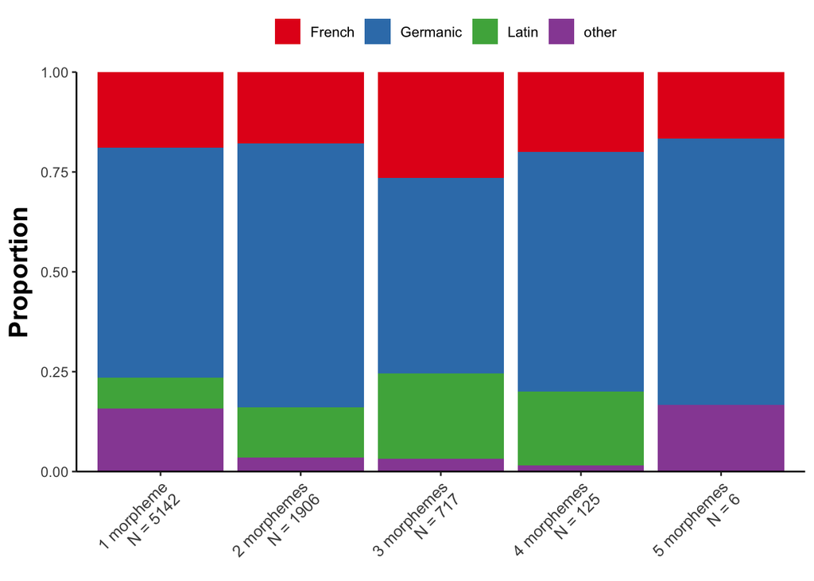

```r
# Plot basics:

nmorph_etym_p <- nmorph_counts %>%
  ggplot(aes(x = factor(NMorph), y = prop, fill = major_etym)) +
  geom_col()

# Axes and labels:

nmorph_etym_p <- nmorph_etym_p +
  ylab('Proportion') +
  xlab(NULL) +
  scale_fill_brewer(palette = 'Set1') +
  scale_y_continuous(expand = c(0, 0))

# Cosmetics:

nmorph_etym_p <- nmorph_etym_p +
  theme_classic() +
  theme(legend.position = 'top',
        legend.title = element_blank(),
        axis.text.x = element_text(size = 10,
                                   angle = 45,
                                   vjust = 1,
                                   hjust = 1),
        axis.title.y = element_text(face = 'bold',
                                    size = 16,
                                    margin = margin(r = 5)),
        axis.title.x = element_text(face = 'bold',
                                    size = 16))

# Show and save:

nmorph_etym_p
```

```r
ggsave('../figures/morpheme_count_etymology.pdf',
       width = 4, height = 4)
```

For the analysis below, make `Germanic` the reference level (most intuitive to start with that and compare Latin, other and French to that):

```r
BECL_clean <- mutate(BECL_clean,
                     major_etym = factor(major_etym,
                                         levels = c('Germanic',
                                                    'French',
                                                    'Latin',
                                                    'other')))
```

Make a negative binomial model of the number of morphemes as a function of etymology. For this, we’ll use the `NMorph_0` variable defined above which looks only at how many morphemes there are more than one morpheme, essentially setting monomorphemic words to zero (as a word cannot have less than one morpheme):

```r
etym_morph_mdl <- brm(NMorph_0 ~ 1 + major_etym,
                      data = BECL_clean,

                      # Likelihood function:
                      family = negbinomial,

                      # Priors:
                      prior = priors,

                      # MCMC settings:
                      init = 0, seed = 666,
                      cores = 4, chains = 4,
                      warmup = 2000, iter = 4000)
```

```
## Trying to compile a simple C file
```

[output not shown]

```r
# Save:

save(etym_morph_mdl,
     file = '../models/nmorph_by_etym_mdl.Rdata')
```

Create the corresponding null model for an omnibus test with LOOCV:

```r
etym_morph_mdl_null <- brm(NMorph_0 ~ 1,
                           data = BECL_clean,

                           # Likelihood function:
                           family = negbinomial,

                           # MCMC settings:
                           init = 0, seed = 666,
                           cores = 4, chains = 4,
                           warmup = 2000, iter = 4000)
```

```
## Trying to compile a simple C file
```

[output not shown]

```r
# Save:

save(etym_morph_mdl_null,
     file = '../models/nmorph_by_etym_null_mdl.Rdata')
```

Perform LOOCV as omnibus test:

```r
etym_morph_LOO <- loo(etym_morph_mdl)
etym_morph_LOO_null <- loo(etym_morph_mdl_null)

# Compare:

etym_morph_loo_compare <- loo_compare(etym_morph_LOO,
                                      etym_morph_LOO_null)

# Show:

etym_morph_loo_compare
```

```
##                     elpd_diff se_diff
## etym_morph_mdl         0.0       0.0
## etym_morph_mdl_null -130.7      15.8
```

So, incorporating etymology does lead to an increase in LOO predictive performance, which suggests that we should control for it.

Check the main model (not the comparison null model):

```r
etym_morph_mdl
```

```
##  Family: negbinomial
##   Links: mu = log; shape = identity
## Formula: NMorph_0 ~ 1 + major_etym
##    Data: BECL_clean (Number of observations: 5270)
##   Draws: 4 chains, each with iter = 4000; warmup = 2000; thin = 1;
##          total post-warmup draws = 8000
##
## Population-Level Effects:
##                  Estimate Est.Error l-95% CI u-95% CI Rhat Bulk_ESS Tail_ESS
## Intercept           -0.35      0.02    -0.40    -0.31 1.00     8745     5933
## major_etymFrench     0.10      0.04     0.01     0.18 1.00     9051     6082
## major_etymLatin      0.36      0.05     0.27     0.45 1.00     8950     6203
## major_etymother     -1.02      0.09    -1.20    -0.85 1.00     8156     6239
##
## Family Specific Parameters:
##       Estimate Est.Error l-95% CI u-95% CI Rhat Bulk_ESS Tail_ESS
## shape   191.02    102.11    61.56   455.19 1.00     8755     6509
##
## Draws were sampled using sampling(NUTS). For each parameter, Bulk_ESS
## and Tail_ESS are effective sample size measures, and Rhat is the potential
## scale reduction factor on split chains (at convergence, Rhat = 1).
```

```r
bayes_R2(etym_morph_mdl)
```

```
##      Estimate   Est.Error       Q2.5      Q97.5
## R2 0.04878778 0.005336718 0.03885389 0.05979568
```

Make a plot of the morpheme count by mass/count. For this, we’ll calculate the proportion of count/mass for each number of morphemes:

```r
nmorph_counts <- BECL_clean %>%
  filter(!is.na(NMorph)) %>%
  count(NMorph, cnt_mass) %>%
  group_by(NMorph) %>%
  mutate(prop = n/ sum(n))

# Show table:

nmorph_counts
```

```
## # A tibble: 10 × 4
## # Groups:   NMorph [5]
##    NMorph cnt_mass     n  prop
##     <dbl> <chr>    <int> <dbl>
##  1      1 count     2224 0.884
##  2      1 mass       292 0.116
##  3      2 count     1392 0.730
##  4      2 mass       514 0.270
##  5      3 count      449 0.626
##  6      3 mass       268 0.374
##  7      4 count       63 0.504
##  8      4 mass        62 0.496
##  9      5 count        2 0.333
## 10      5 mass         4 0.667
```

Append the N next to that:

```r
N_nmorph <- BECL_wide %>%
  count(NMorph) %>%
  filter(!is.na(NMorph)) %>%
  rename(N = n)

# Merge:

nmorph_counts <- left_join(nmorph_counts, N_nmorph)
# Create the labels for the x-axis:

nmorph_counts <- mutate(nmorph_counts,
                        NMorph = str_c(NMorph, ' morphemes\nN = ',
                                       N))

# Change only the first two, since it needs singular:

nmorph_counts[1:2, ]$NMorph <- '1 morpheme\nN = 5142'

# Check:

nmorph_counts
```

```
## # A tibble: 10 × 5
## # Groups:   NMorph [5]
##    NMorph                  cnt_mass     n  prop     N
##    <chr>                   <chr>    <int> <dbl> <int>
##  1 "1 morpheme\nN = 5142"  count     2224 0.884  5142
##  2 "1 morpheme\nN = 5142"  mass       292 0.116  5142
##  3 "2 morphemes\nN = 2655" count     1392 0.730  2655
##  4 "2 morphemes\nN = 2655" mass       514 0.270  2655
##  5 "3 morphemes\nN = 890"  count      449 0.626   890
##  6 "3 morphemes\nN = 890"  mass       268 0.374   890
##  7 "4 morphemes\nN = 148"  count       63 0.504   148
##  8 "4 morphemes\nN = 148"  mass        62 0.496   148
##  9 "5 morphemes\nN = 7"    count        2 0.333     7
## 10 "5 morphemes\nN = 7"    mass         4 0.667     7
```

Make the plot:

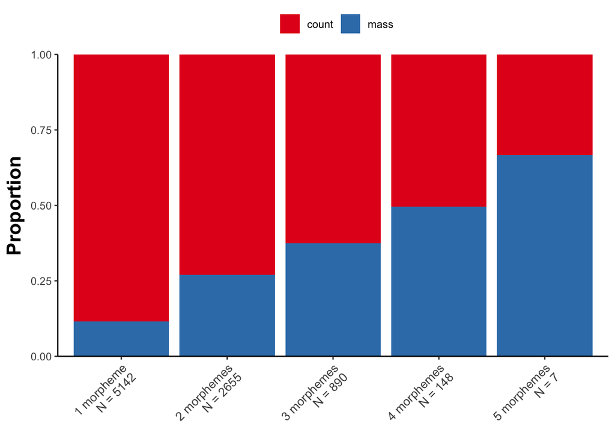

```r
# Plot basics:

nmorph_p <- nmorph_counts %>%
  ggplot(aes(x = factor(NMorph),
             y = prop, fill = cnt_mass)) +
  geom_col()

# Axes and labels:

nmorph_p <- nmorph_p +
  ylab('Proportion') +
  xlab(NULL) +
  scale_fill_brewer(palette = 'Set1') +
  scale_y_continuous(expand = c(0, 0))

# Cosmetics:

nmorph_p <- nmorph_p +
  theme_classic() +
  theme(legend.position = 'top',
        legend.title = element_blank(),
        axis.text.x = element_text(size = 10,
                                   angle = 45,
                                   vjust = 1,
                                   hjust = 1),
        axis.title.y = element_text(face = 'bold',
                                    size = 16,
                                    margin = margin(r = 5)),
        axis.title.x = element_text(face = 'bold',
                                    size = 16))

# Show and save:

nmorph_p
```

```r
ggsave('../figures/morpheme_count_mass.pdf',
       width = 4, height = 4)
```

Make a model of this, morpheme count as a function of count/mass, controlling for etymology:

```r
nmorph_mdl <- brm(NMorph_0 ~ 1 + cnt_mass + major_etym,
                  data = BECL_clean,

                  # Likelihood function:
                  family = negbinomial,

                  # Priors:
                  prior = priors,

                  # MCMC settings:
                  init = 0, seed = 666,
                  cores = 4, chains = 4,
                  warmup = 2000, iter = 4000)
```

```
## Trying to compile a simple C file
```

[output not shown]

```r
# Save:

save(nmorph_mdl,
     file = '../models/nmorph_mdl.RData')
```

Check the model:

```r
nmorph_mdl
```

```
##  Family: negbinomial
##   Links: mu = log; shape = identity
## Formula: NMorph_0 ~ 1 + cnt_mass + major_etym
##    Data: BECL_clean (Number of observations: 5270)
##   Draws: 4 chains, each with iter = 4000; warmup = 2000; thin = 1;
##          total post-warmup draws = 8000
##
## Population-Level Effects:
##                  Estimate Est.Error l-95% CI u-95% CI Rhat Bulk_ESS Tail_ESS
## Intercept           -0.50      0.02    -0.55    -0.45 1.00    11107     6494
## cnt_massmass         0.55      0.03     0.49     0.62 1.00    10318     5850
## major_etymFrench     0.06      0.04    -0.02     0.14 1.00    10702     5666
## major_etymLatin      0.34      0.05     0.25     0.43 1.00    10676     6223
## major_etymother     -0.96      0.09    -1.14    -0.78 1.00    10905     6183
##
## Family Specific Parameters:
##       Estimate Est.Error l-95% CI u-95% CI Rhat Bulk_ESS Tail_ESS
## shape   216.88    107.74    76.18   488.31 1.00    11276     6249
##
## Draws were sampled using sampling(NUTS). For each parameter, Bulk_ESS
## and Tail_ESS are effective sample size measures, and Rhat is the potential
## scale reduction factor on split chains (at convergence, Rhat = 1).
```

```r
bayes_R2(nmorph_mdl)
```

```
##     Estimate   Est.Error       Q2.5     Q97.5
## R2 0.1075819 0.009521502 0.08969255 0.1271433
```

Perform a hypothesis test:

```r
hypothesis(nmorph_mdl, 'cnt_massmass > 0')
```

```
## Hypothesis Tests for class b:
##           Hypothesis Estimate Est.Error CI.Lower CI.Upper Evid.Ratio Post.Prob
## 1 (cnt_massmass) > 0     0.55      0.03      0.5     0.61        Inf         1
##   Star
## 1    *
## ---
## 'CI': 90%-CI for one-sided and 95%-CI for two-sided hypotheses.
## '*': For one-sided hypotheses, the posterior probability exceeds 95%;
## for two-sided hypotheses, the value tested against lies outside the 95%-CI.
## Posterior probabilities of point hypotheses assume equal prior probabilities.
```

Plot the posterior distribution:

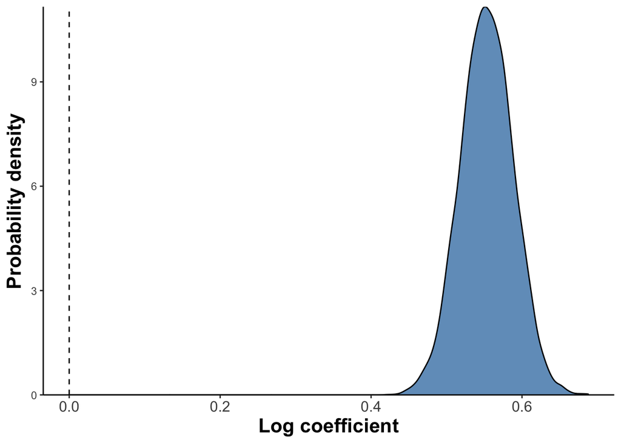

```r
# Plot basics:

nmorph_post_p <- posterior_samples(nmorph_mdl) %>%
  ggplot(aes(x = b_cnt_massmass)) +
  geom_vline(xintercept = 0, linetype = 'dashed') +
  geom_density(fill = 'steelblue',
               alpha = 0.8)
# Scales and axes:

nmorph_post_p <- nmorph_post_p +
  scale_y_continuous(expand = c(0, 0)) +
  ylab('Probability density') +
  xlab('Log coefficient')

# Cosmetics:

nmorph_post_p <- nmorph_post_p +
  theme_classic() +
  theme(axis.text.x = element_text(size = 12),
        axis.title.y = element_text(face = 'bold',
                                    size = 16,
                                    margin = margin(r = 5)),
        axis.title.x = element_text(face = 'bold',
                                    size = 16))

# Show and save:

nmorph_post_p
```

```r
ggsave('../figures/nmorph_posterior.pdf', nmorph_post_p,
       width = 5, height = 3)
```

Combine stacked bar plot with posterior into a double plot:

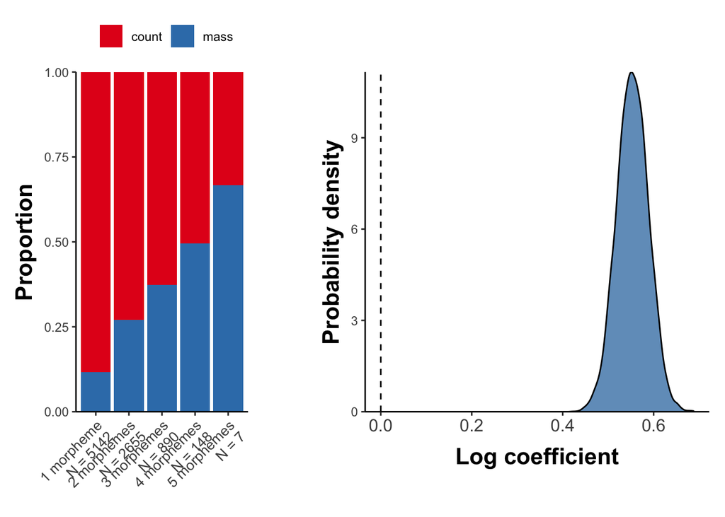

```r
# Fix title re-adjusting in double plot:

nmorph_post_p <- nmorph_post_p +
  theme(axis.title.x = element_text(margin = margin(t = -60)))

# Use patchwork for double plotting:

nmorph_double_p <- nmorph_p + plot_spacer() + nmorph_post_p +
  plot_layout(widths = c(2, 0.5, 4))

# Show and save:

nmorph_double_p
```

```r
ggsave('../figures/nmorph_double_plot.pdf',
       width = 9, height = 4)
```

Make a plot of the conditional effects for this:

```r
# Extract conditional effects:

nmorph_cond <- conditional_effects(nmorph_mdl,
                                   effects = 'cnt_mass')

# Extract data frame with conditional effects and 95% credible intervals:

nmorph_pred_df <- nmorph_cond$cnt_mass
```

Make a ggplot out of this:

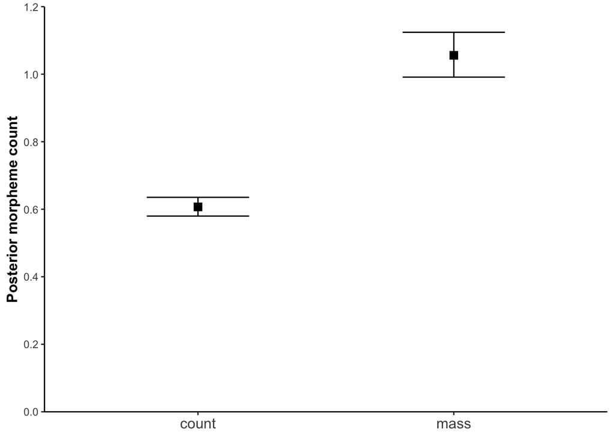

```r
# Plot basics:

nmorph_cond_p <- nmorph_pred_df %>%
  ggplot(aes(x = cnt_mass, y = estimate__)) +
  geom_point(size = 3, pch = 15) +
  geom_errorbar(aes(ymin = lower__, ymax = upper__),
                width = 0.4)

# Axes and labels:

nmorph_cond_p <- nmorph_cond_p +
  scale_y_continuous(limits = c(0, 1.2), breaks = seq(0, 1.2, 0.2),
                     expand = c(0, 0)) +
  ylab('Posterior morpheme count') +
  xlab(NULL)

# Cosmetics:

nmorph_cond_p <- nmorph_cond_p +
  theme_classic() +
  theme(axis.text.x = element_text(size = 12),
        axis.title.y = element_text(face = 'bold',
                                    size = 12))

# Show and save:

nmorph_cond_p
```

```r
ggsave('../figures/nmorph_conditional_effects.pdf',
       width = 2, height = 3.5)
```

## Frequency analysis

From now on, we’ll switch to the monomorphemics so that we can look at “pure” length, unfettered by whether words are multimorphemic or not.

Average frequency:

```r
mono %>% group_by(cnt_mass) %>%
  summarize(freq_raw_M = mean(freq, na.rm = TRUE),
            freq_raw_SD = sd(freq, na.rm = TRUE))
```

```
## # A tibble: 2 × 3
##   cnt_mass freq_raw_M freq_raw_SD
##   <chr>         <dbl>       <dbl>
## 1 count         2536.      16482.
## 2 mass          1884.       9112.
```

Make a boxplot of this:

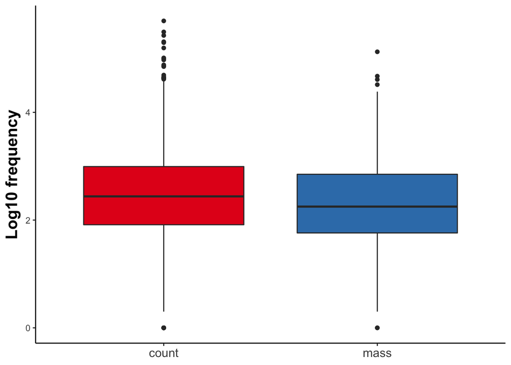

```r
# Plot basics:

freq_p <- mono %>%
  ggplot(aes(x = cnt_mass, y = logfreq, fill = cnt_mass)) +
  geom_boxplot()

# Axes and scales:

freq_p <- freq_p +
  scale_fill_brewer(palette = 'Set1') +
  ylab('Log10 frequency') +
  xlab(NULL)

# Cosmetics:

freq_p <- freq_p +
  theme_classic() +
  theme(legend.position = 'none',
        axis.text.x = element_text(size = 12),
        axis.title.y = element_text(face = 'bold',
                                    size = 16,
                                    margin = margin(r = 5)),
        axis.title.x = element_text(face = 'bold',
                                    size = 16))

# Show and save:

freq_p
```

```r
ggsave('../figures/frequency_boxplot.pdf', freq_p,
       width = 3, height = 5)
```

Make a model of frequency:

```r
freq_mdl <- brm(freq ~ 1 + cnt_mass,
                data = mono,

                # Likelihood function:
                family = negbinomial,

                # Priors:
                prior = priors,

                # MCMC settings:
                init = 0, seed = 666,
                cores = 4, chains = 4,
                warmup = 2000, iter = 4000)
```

```
## Trying to compile a simple C file
```

[output not shown]

```r
# Save:

save(freq_mdl,
     file = '../models/frequency_mdl.RData')
```

Show the model:

```r
freq_mdl
```

```
##  Family: negbinomial
##   Links: mu = log; shape = identity
## Formula: freq ~ 1 + cnt_mass
##    Data: mono (Number of observations: 2516)
##   Draws: 4 chains, each with iter = 4000; warmup = 2000; thin = 1;
##          total post-warmup draws = 8000
##
## Population-Level Effects:
##              Estimate Est.Error l-95% CI u-95% CI Rhat Bulk_ESS Tail_ESS
## Intercept        7.84      0.04     7.77     7.91 1.00     9053     6245
## cnt_massmass    -0.29      0.11    -0.50    -0.06 1.00     9013     6272
##
## Family Specific Parameters:
##       Estimate Est.Error l-95% CI u-95% CI Rhat Bulk_ESS Tail_ESS
## shape     0.31      0.01     0.30     0.32 1.00     8621     6258
##
## Draws were sampled using sampling(NUTS). For each parameter, Bulk_ESS
## and Tail_ESS are effective sample size measures, and Rhat is the potential
## scale reduction factor on split chains (at convergence, Rhat = 1).
```

```r
bayes_R2(freq_mdl)
```

```
##        Estimate    Est.Error         Q2.5       Q97.5
## R2 0.0001824791 0.0001140373 9.632594e-06 0.000446883
```

Perform hypothesis test of frequency:

```r
hypothesis(freq_mdl, 'cnt_massmass < 0')
```

```
## Hypothesis Tests for class b:
##           Hypothesis Estimate Est.Error CI.Lower CI.Upper Evid.Ratio Post.Prob
## 1 (cnt_massmass) < 0    -0.29      0.11    -0.47     -0.1     134.59      0.99
##   Star
## 1    *
## ---
## 'CI': 90%-CI for one-sided and 95%-CI for two-sided hypotheses.
## '*': For one-sided hypotheses, the posterior probability exceeds 95%;
## for two-sided hypotheses, the value tested against lies outside the 95%-CI.
## Posterior probabilities of point hypotheses assume equal prior probabilities.
```

## Length analyses: syllables

Does word length depend on etymology? Syllables:

```r
mono %>%
  group_by(major_etym) %>%
  summarize(NSyll_M = mean(NSyll, na.rm = TRUE),
            NSyll_SD = sd(NSyll, na.rm = TRUE)) %>%
  arrange(NSyll_M)
```

```
## # A tibble: 4 × 3
##   major_etym NSyll_M NSyll_SD
##   <chr>        <dbl>    <dbl>
## 1 other         1.55    0.769
## 2 Germanic      1.57    0.699
## 3 French        1.82    0.758
## 4 Latin         2.21    0.953
```

Make a model of syllable length as a function of etymology, controlling for frequency:

```r
nsyll_etym_mdl <- brm(NSyll_0 ~ 1 + major_etym + logfreq,
                      data = mono,

                      # Likelihood function:
                      family = negbinomial,

                      # Priors:
                      prior = priors,

                      # MCMC settings:
                      init = 0, seed = 666,
                      cores = 4, chains = 4,
                      warmup = 2000, iter = 4000)
```

```
## Trying to compile a simple C file
```

[output not shown]

```r
# Save:

save(nsyll_etym_mdl,
     file = '../models/nsyllable_by_etymology_mdl.RData')
```

Show the model:

```r
nsyll_etym_mdl
```

```
##  Family: negbinomial
##   Links: mu = log; shape = identity
## Formula: NSyll_0 ~ 1 + major_etym + logfreq
##    Data: mono (Number of observations: 2516)
##   Draws: 4 chains, each with iter = 4000; warmup = 2000; thin = 1;
##          total post-warmup draws = 8000
##
## Population-Level Effects:
##                    Estimate Est.Error l-95% CI u-95% CI Rhat Bulk_ESS Tail_ESS
## Intercept              0.80      0.08     0.65     0.96 1.00     8443     6787
## major_etymGermanic    -0.28      0.06    -0.40    -0.16 1.00     8187     6380
## major_etymLatin        0.25      0.08     0.08     0.41 1.00     7956     6386
## major_etymother       -0.38      0.08    -0.55    -0.22 1.00     7930     5767
## logfreq               -0.46      0.03    -0.52    -0.40 1.00     9041     6180
##
## Family Specific Parameters:
##       Estimate Est.Error l-95% CI u-95% CI Rhat Bulk_ESS Tail_ESS
## shape   166.73     97.37    49.10   417.33 1.00    10255     6055
##
## Draws were sampled using sampling(NUTS). For each parameter, Bulk_ESS
## and Tail_ESS are effective sample size measures, and Rhat is the potential
## scale reduction factor on split chains (at convergence, Rhat = 1).
```

```r
bayes_R2(nsyll_etym_mdl)
```

```
##     Estimate  Est.Error      Q2.5     Q97.5
## R2 0.1739305 0.01849343 0.1382447 0.2111409
```

Get the comparison null model for LOO comparisons:

```r
nsyll_etym_mdl_null <- brm(NSyll_0 ~ 1 + logfreq,
                           data = mono,

                           # Likelihood function:
                           family = negbinomial,

                           # Priors:
                           prior = priors,

                           # MCMC settings:
                           init = 0, seed = 666,
                           cores = 4, chains = 4,
                           warmup = 2000, iter = 4000)
```

```
## Trying to compile a simple C file
```

[output not shown]

```r
# Save:

save(nsyll_etym_mdl_null,
     file = '../models/nsyllable_by_etymology_mdl_null.RData')
```

Do LOO-CV for both:

```r
nsyll_etym_loo <- loo(nsyll_etym_mdl)
nsyll_etym_null_loo <- loo(nsyll_etym_mdl_null)

# LOO compare:

nsyll_etym_loo_compare <- loo_compare(nsyll_etym_loo,
                                      nsyll_etym_null_loo)

# Show:

nsyll_etym_loo_compare
```

```
##                     elpd_diff se_diff
## nsyll_etym_mdl        0.0       0.0
## nsyll_etym_mdl_null -30.2       7.0
```

This motivates the inclusion of etymology into the main model.